# Simulate Network Expression on a Large Scale

Chris McKennan

2016-02-10

**Last updated:** 2016-02-27

**Code version:** f955b88fbb738ddd31d0998631111b45ac000a08

## Test Model Performance

The purpose of this file is to test the performance of the Gibbs sampler. I will simulate $N$ networks (i.e. covariance matrices), each with a corresponding effect size for the ‘source’ gene (i.e. the gene cis to the SNP), a list of indirect effects and a minor allele frequency.

## Upload Source Functions

```r
library('gtools')
source("../R/directionality_CGM.R")
source("../R/SimulateNetworkExpression.R")
```

## User specified input parameters for the simulation

Below are input parameters the user can specify. For each simulation $j = 1,\ldots, N$, I simulate an effect size $\theta_j \sim N\left( 0, \sigma^2 \right)1\left\lbrace |\theta_j| > \frac{\sigma}{4} \right\rbrace$, a minor allele frequency $f_i \sim U[m_0, m_1]$ and a covariance matrix $\Sigma_j \in \mathbb{R}^{n_{\text{neigh}} + 1 \times n_{\text{neigh}} + 1} \sim \mathcal{W}_{n_{\text{neigh}} + 1}\left( V_j, n_{\text{ind}} \right)$. $V_j$ had 1’s along the diagonal and $\rho = 0.8$ everywhere else. Note as $\rho$ gets larger, the indirect effects become more pronounced.

For each independent individual $i$ with geneotype $x_i$, I simulate data from
$$\left( \begin{matrix}
Y_{I,i}\\
Y_{D,i}\\
Y_{U,i}
\end{matrix} \right) \mid \theta, x_{i}, \Sigma \sim N\left( \left( \begin{matrix}
\mu_I\\
\theta_s x_{i}\\
0
\end{matrix} \right), \Sigma = \left( \begin{matrix}
\Sigma_{11} & \Sigma_{12}\\
\Sigma_{21} & \Sigma_{22}
\end{matrix} \right) \right)$$
where by conditional independence,
$$\mu_I = \theta x_{i} \Sigma_{12} \Sigma_{22}^{-1}\vec{e}_1.$$
The most important features of this simulation procedure are the minor allele frequency $f_i$ and (standardized) effect size $\theta_i$, as these determine the power to detect effects over the noise in the data.

```r
N = 20   ##Number of simulated networks
sim.theta <- FALSE
theta.try <- c(0.25/sqrt(pi), 0.5/sqrt(pi), 0.75/sqrt(pi), 1/sqrt(pi))   #The variance of the error is 1, so the exptected size of the error is roughly 1/sqrt(pi)

##Parameters fixed throughout simulations##

n.nei <- 9     ##Number of neighbors
n.ind <- 300   ##Number of indiviuals
source.ind <- 3   ##Source gene
D.gam <- (3:4)
I.gam <- (1:2)          ##Indices of indirectly affected neighbors; correspond to indices of Sigma
U.gam <- (5:(n.nei+1))      ##Indices of unaffected neighbors; correspond to indices of Sigma
m <- n.nei + 1    ##DOF used in Wishart prior in Bayes Factor analysis
sigma.a <- c(0.3, 0.5, 0.7)             #Prior sd's on effect; used in BF calculation
weights.sigma <- c(1,1,1)                   #Relative weights of each element of sigma.a
rho <- 0.8

##Hyperparameters to above distributions##

sigma <- 0.5   ##sigma in the above simulation. Note this is related to the STANDARDIZED effect size, since the diagoanl elements of the true covariance matrix V_j are 1.
m0 <- 0.2; m1 <- 0.5

###Some Parameters for the Gibbs Sampler###
n.iter <- 2000
n.burn <- 1000
theta.gibbs <- rep(0.5, 3)  #If Dirichlet = T, this is the prior on alpha. Otherwise, this is proportional to the probability of unaffected, indirectly affected, directly affected by the cis-eQTL
Dirichlet <- TRUE
```

## Simulate and Analyze Network Expression

The Gibbs sampler assumes that the SNP - gene0 connection is a direct effect, where gene0 is the source gene. If Dirichlet = T, then $\left( p_D, p_I, p_U\right) \sim \text{Dirichlet}\left( 0.5, 0.5, 0.5\right)$. It computes $P\left( \text{Genes are unaffected by SNP} \mid \text{Data} \right)$ and $E\left[ \left( p_D, p_I, p_U\right) \mid \text{Data} \right]$.

```r
results.sim <- list()   #List of results for each j = 1,...,N
count = 1
for (j in 1:N) {
  f.j <- (m1 - m0)*runif(1) + m0

  X.j <- rbinom(n.ind, size=1, prob=f.j) + rbinom(n.ind, size=1, prob=f.j)   #Genotype under HWE

  #V.j <- generateV(n.nei + 1)
  #Sigma.j <- create.sigma.W(n.ind, n.nei+1, V.j)
  Sigma.j <- (1-rho) * diag(n.nei+1) + rho * cbind(rep(1,n.nei+1)) %*% rbind(rep(1,n.nei+1))

  if (sim.theta) {
    theta.j <- sigma*rnorm(1)
    while (abs(theta.j) < sigma/4) {
      theta.j <- sigma*rnorm(1)
    }
    Y.gex.j <- Sim.gex(Sigma.j, D.gam, I.gam, U.gam, theta.j, X.j, lambda=1)      #n.ind x (n.nei + 1) gene expression matrix in the order of input Sigma.j
    suff.stat.j <- Suff.stat(Y.gex.j, X.j)   #Sufficient statistics necessary to calculate Bayes Factor

    gibbs.j <- Gibbs.dir.1(n.iter, n.burn, suff.stat.j, source.ind, n.ind, sigma.a, weights.sigma, m, theta.gibbs, Dirichlet)

    results.sim[[count]] <- list(post.mean.I=gibbs.j$post.mean.I, post.mean.D=gibbs.j$post.mean.D, maf=f.j, theta=theta.j, post.probs=gibbs.j$post.probs)
    count = count + 1
  } else {
    for (theta.j in theta.try) {
      Y.gex.j <- Sim.gex(Sigma.j, D.gam, I.gam, U.gam, theta.j, X.j, lambda=1)
      suff.stat.j <- Suff.stat(Y.gex.j, X.j)
      gibbs.j <- Gibbs.dir.1(n.iter, n.burn, suff.stat.j, source.ind, n.ind, sigma.a, weights.sigma, m, theta.gibbs, Dirichlet)

      results.sim[[count]] <- list(post.mean.I=gibbs.j$post.mean.I, post.mean.D=gibbs.j$post.mean.D, maf=f.j, theta=theta.j, post.probs=gibbs.j$post.probs)
      count = count + 1
    }
  }
}
```

## Visualize Results

Get data from simulations into a readable format.

```r
if (sim.theta) {
  results.array <- array(NA, dim=c(N, n.nei+1, 2))   #Simulation index, post.mean.I, post.mean.D
  post.probs.array <- array(NA, dim=c(length(theta.try)*N), 3)
  for (i in 1:N) {
    results.array[i,,] <- cbind(results.sim[[i]]$post.mean.I, results.sim[[i]]$post.mean.D)
  }
} else {
  n.theta <- length(theta.try)
  results.array <- array(NA, dim=c(N, n.theta, n.nei+1, 2))   #Simulation index, theta, post.mean.I, post.mean.D
  post.probs.array <- array(NA, dim=c(N, n.theta, 3))
  count = 1
  for (i in 1:N) {
    for (k in 1:n.theta) {
      results.array[i,k,,] = cbind(results.sim[[count]]$post.mean.I, results.sim[[count]]$post.mean.D)
      post.probs.array[i,k,] <- results.sim[[count]]$post.probs   #U, I, D
      count <- count + 1
    }
  }
}
```

Plot histograms and ROC curves of simulation results

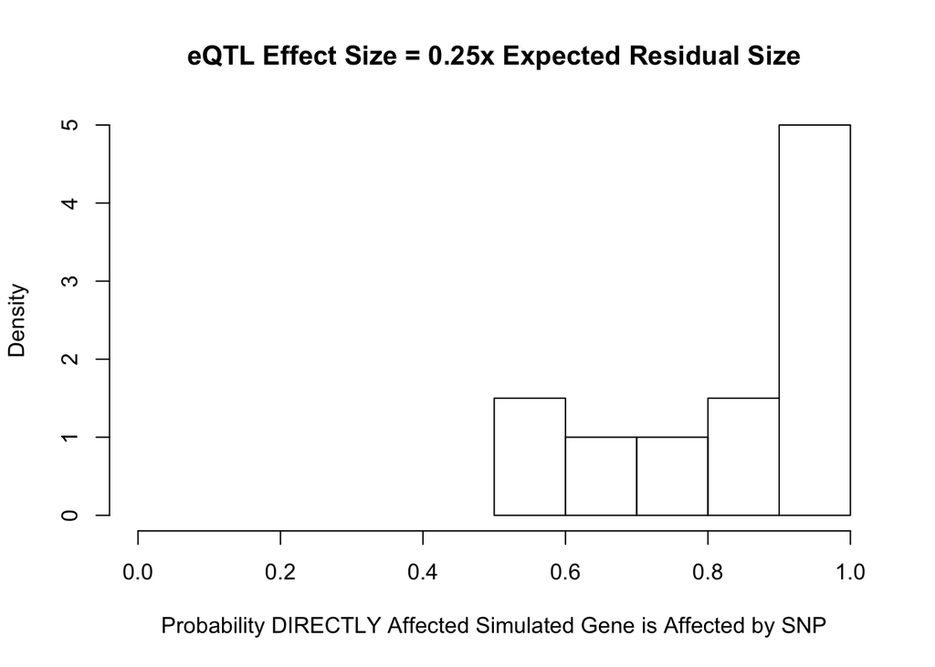

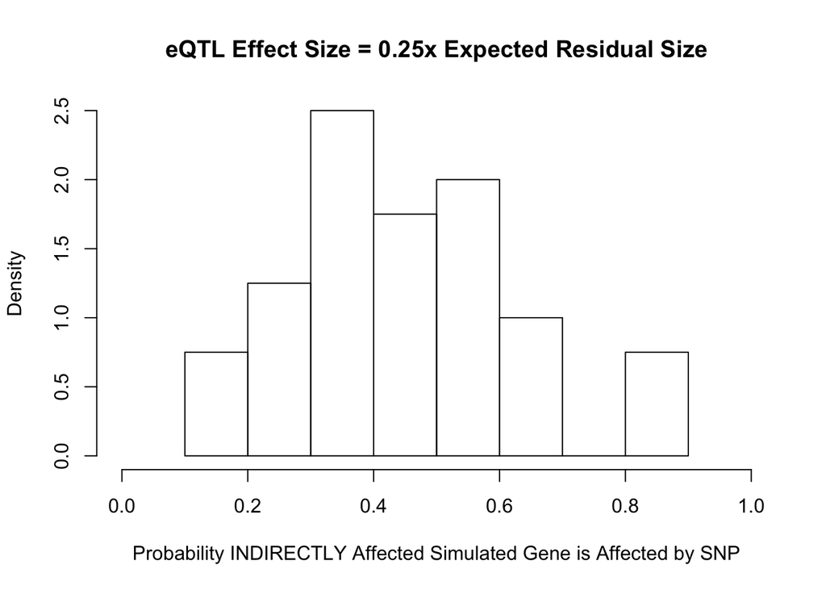

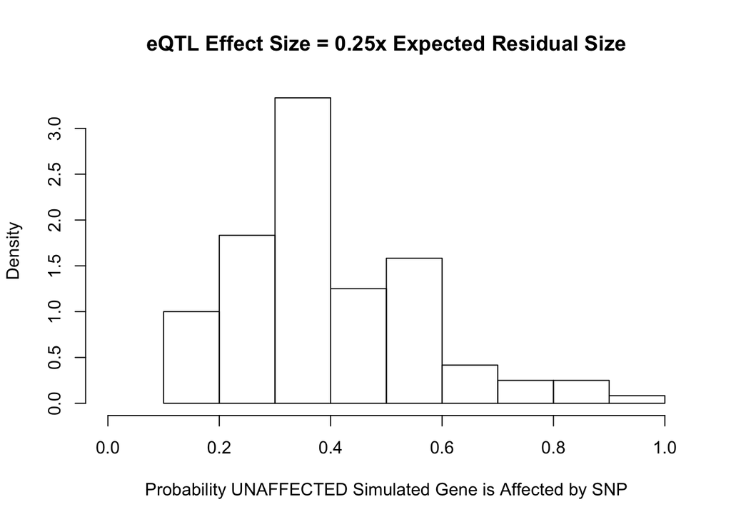

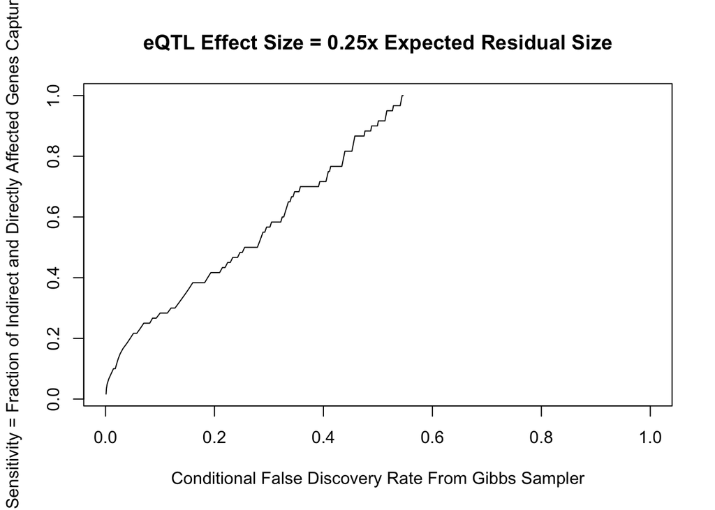

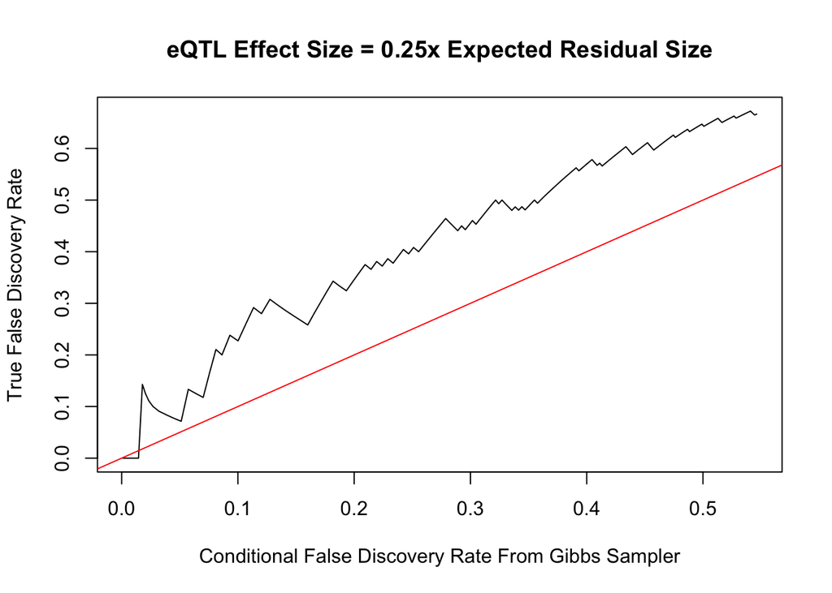

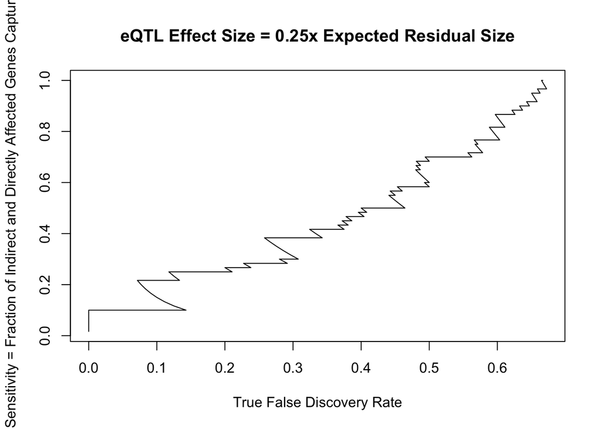

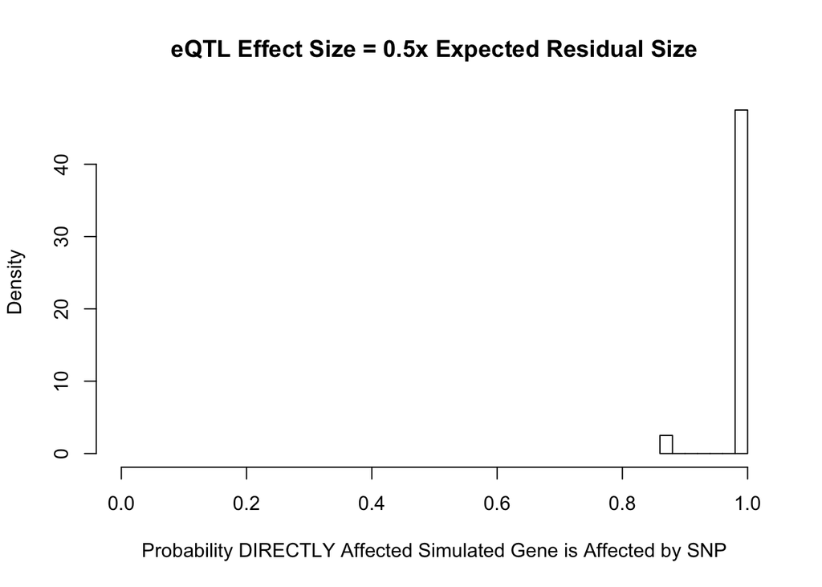

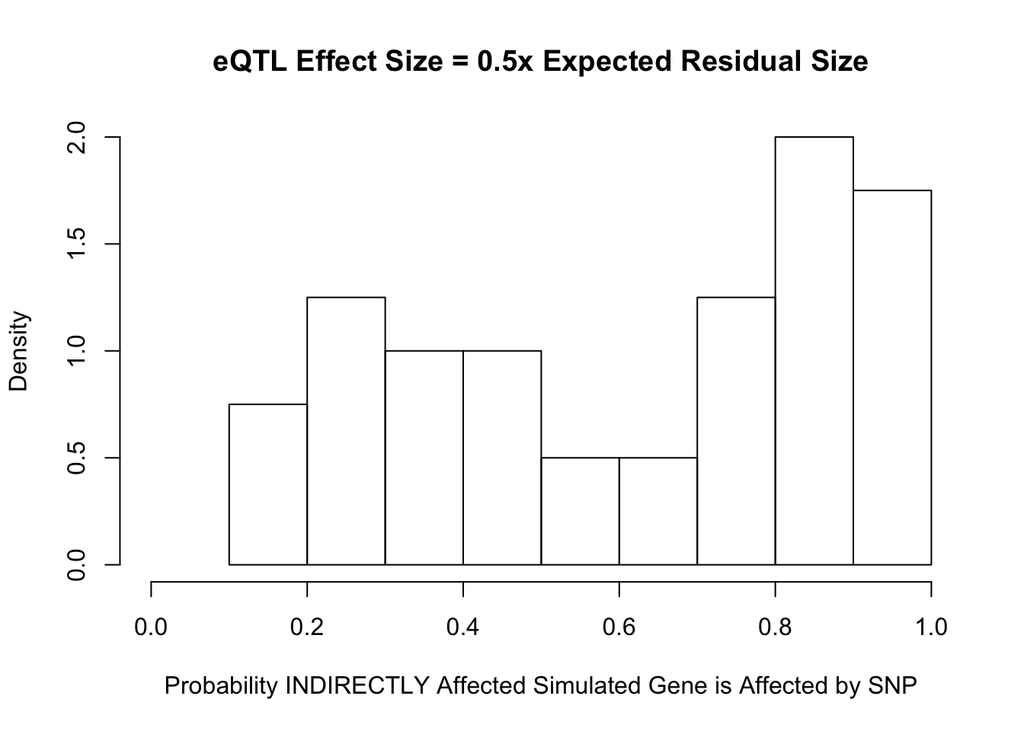

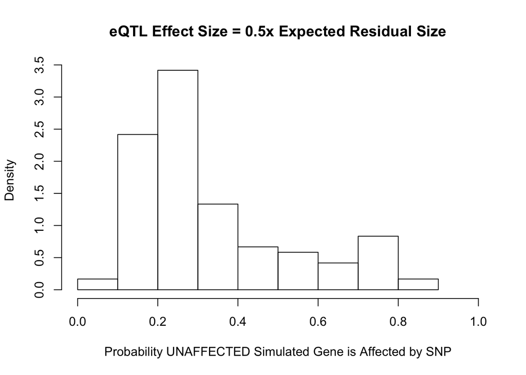

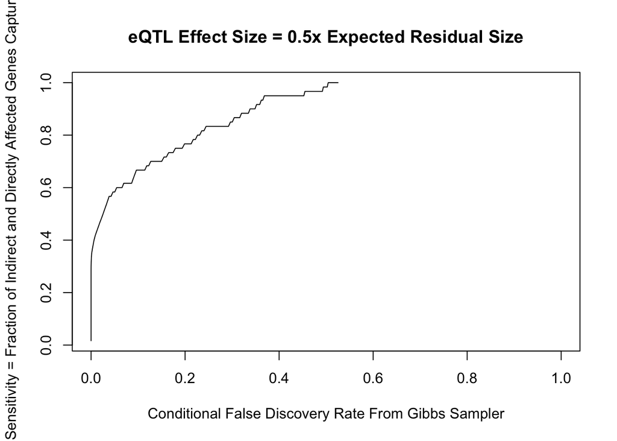

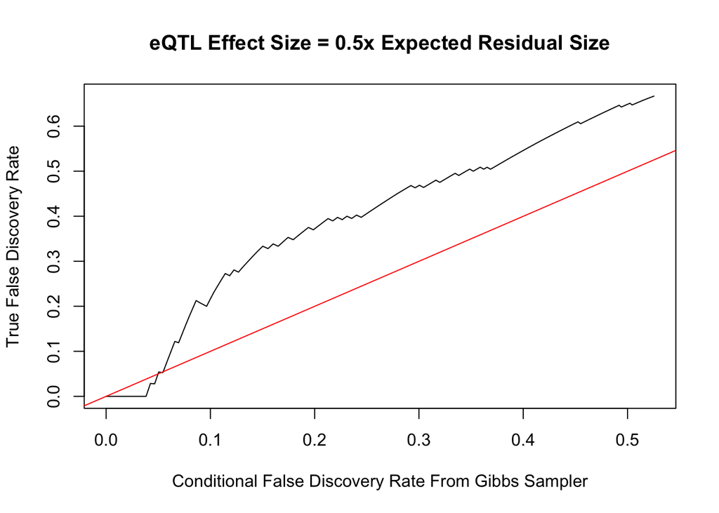

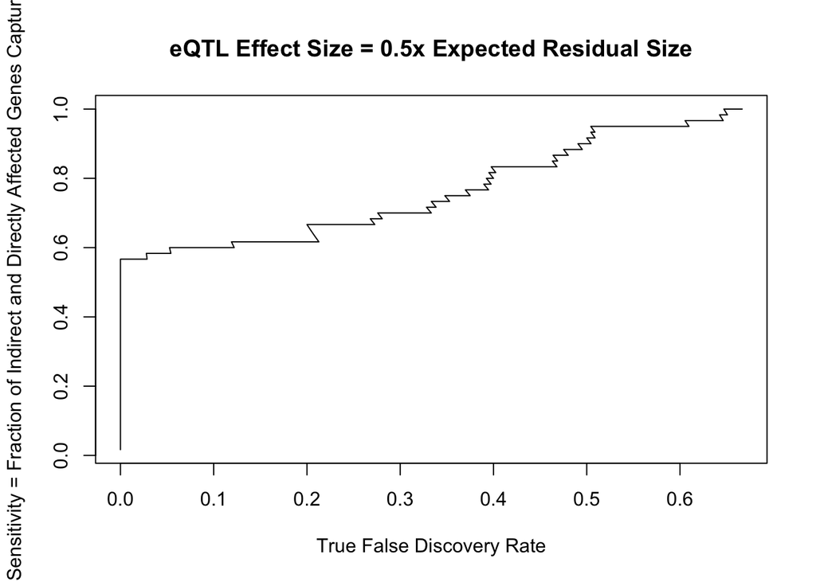

[12 more figures not shown]

```r
n.D <- length(D.gam[-which(D.gam==source.ind)])
n.I <- length(I.gam)
n.U <- length(U.gam)
if (!sim.theta) {
  for (k in 1:n.theta) {
    tmp.theta <- as.character(signif(sqrt(pi)*theta.try[k], 2))
    data.plot.D <- rep(0, n.D*N)
    data.plot.I <- rep(0, n.I*N)
    data.plot.U <- rep(0, n.U*N)
    for (i in 1:N) {
      if (n.D == 1) {
        data.plot.D[(n.D*(i-1)+1):(n.D*i)] <- sum(results.array[i,k,D.gam[-which(D.gam==source.ind)],])
      } else {
        data.plot.D[(n.D*(i-1)+1):(n.D*i)] <- apply(results.array[i,k,D.gam[-which(D.gam==source.ind)],] , 1, sum)
      }
      if (n.I == 1) {
        data.plot.I[(n.I*(i-1)+1):(n.I*i)] <- sum(results.array[i,k,I.gam,])      #Posterior probability directly affected genes are AFFECTED by SNP
      } else {
        data.plot.I[(n.I*(i-1)+1):(n.I*i)] <- apply(results.array[i,k,I.gam,], 1, sum)   #Posterior probability indirectly affected genes are AFFECTED by SNP
      }
      data.plot.U[(n.U*(i-1)+1):(n.U*i)] <- 1 - apply(results.array[i,k,U.gam,], 1, sum)   #posterior probability unaffected genes are UNAFFECTED by SNP
    }

    hist(data.plot.D, prob=T, xlim=c(0,1), xlab='Probability DIRECTLY Affected Simulated Gene is Affected by SNP', ylab='Density', main=paste0("eQTL Effect Size = ", tmp.theta, "x Expected Residual Size"))
    hist(data.plot.I, prob=T, xlim=c(0,1), xlab='Probability INDIRECTLY Affected Simulated Gene is Affected by SNP', ylab='Density', main=paste0("eQTL Effect Size = ", tmp.theta, "x Expected Residual Size"))
    hist(1-data.plot.U, prob=T, xlim=c(0,1), xlab='Probability UNAFFECTED Simulated Gene is Affected by SNP', ylab='Density', main=paste0("eQTL Effect Size = ", tmp.theta, "x Expected Residual Size"))

    all.data <- c(1-data.plot.D, 1-data.plot.I, data.plot.U); order.data <- order(all.data)   #Posterior probabilities genes are UNAFFECTED by SNP
    gene.label <- c(rep(2, n.D*N), rep(1, n.I*N), rep(0, n.U*N))[order.data]
    all.data <- sort(all.data)

    fdr.all <- Cond.FDR(all.data)
    fdr.labels.all <- FDR.labels(gene.label)
    sens.all <- Sens.labels(gene.label)
    plot(fdr.all, sens.all, xlab="Conditional False Discovery Rate From Gibbs Sampler", ylab="Sensitivity = Fraction of Indirect and Directly Affected Genes Captured", main=paste0("eQTL Effect Size = ", tmp.theta, "x Expected Residual Size"), xlim=c(0,1), type="l")
    plot(fdr.all, fdr.labels.all, xlab="Conditional False Discovery Rate From Gibbs Sampler", ylab="True False Discovery Rate", main=paste0("eQTL Effect Size = ", tmp.theta, "x Expected Residual Size"), type="l")
    abline(a=0,b=1, col="red")
    plot(fdr.labels.all, sens.all, xlab="True False Discovery Rate", ylab="Sensitivity = Fraction of Indirect and Directly Affected Genes Captured", main=paste0("eQTL Effect Size = ", tmp.theta, "x Expected Residual Size"), type="l")
  }
}
```

There are a number of conclusions we can draw from these plots. The first is that we have a dificult time performing inference when $\theta$ is small. For $X \sim N\left(0, 1\right)$ and $\frac{\theta}{E|X|} = \frac{1}{4}$, we essentially cannot do inference with the number of samples we have. Further, the results for larger values of $\theta$ are poorly calibrated since we cannot seem to accurately estimate the correct false discovery rate.